```python
# importing the libraries

import pandas as pd
import seaborn as sns
import numpy as np
import random
import matplotlib.pyplot as plt
from sklearn.metrics import confusion_matrix
from sklearn.model_selection import train_test_split, GridSearchCV, StratifiedKFold
from sklearn.metrics import accuracy_score, precision_score, recall_score, f1_score
from sklearn.metrics import confusion_matrix, roc_auc_score, mean_absolute_error, mean_squared_error
import xgboost as xgb
from sklearn.preprocessing import RobustScaler
import scipy.stats as stats

np.random.seed(42)
random.seed(42)
```

# Importing and splitting the data into training and testing

```python
# importing the file with the combined data of both the hospitals and splitting it into 2 parts

df = pd.read_csv('./physionet_data.csv')

# check row counts after split
total_rows = len(df)

print(f"Total rows: {total_rows}")
```

```
Total rows: 1552210
```

# Exploratory data analysis

# Training Dataset

```python
df.head(15)
```

|  | Unnamed: 0 | Hour | HR | O2Sat | Temp | SBP | MAP | DBP | Resp | EtCO2 | ... | Fibrinogen | Platelets | Age | Gender | Unit1 | Unit2 | HospAdmTime | ICULOS | SepsisLabel | Patient_ID |
| --- | --- | --- | --- | --- | --- | --- | --- | --- | --- | --- | --- | --- | --- | --- | --- | --- | --- | --- | --- | --- | --- |
| 0 | 0 | 0 | NaN | NaN | NaN | NaN | NaN | NaN | NaN | NaN | ... | NaN | NaN | 68.54 | 0 | NaN | NaN | -0.02 | 1 | 0 | 17072 |
| 1 | 1 | 1 | 65.0 | 100.0 | NaN | NaN | 72.0 | NaN | 16.5 | NaN | ... | NaN | NaN | 68.54 | 0 | NaN | NaN | -0.02 | 2 | 0 | 17072 |
| 2 | 2 | 2 | 78.0 | 100.0 | NaN | NaN | 42.5 | NaN | NaN | NaN | ... | NaN | NaN | 68.54 | 0 | NaN | NaN | -0.02 | 3 | 0 | 17072 |
| 3 | 3 | 3 | 73.0 | 100.0 | NaN | NaN | NaN | NaN | 17.0 | NaN | ... | NaN | NaN | 68.54 | 0 | NaN | NaN | -0.02 | 4 | 0 | 17072 |
| 4 | 4 | 4 | 70.0 | 100.0 | NaN | 129.0 | 74.0 | 69.0 | 14.0 | NaN | ... | NaN | 330.0 | 68.54 | 0 | NaN | NaN | -0.02 | 5 | 0 | 17072 |
| 5 | 5 | 5 | 62.0 | 100.0 | NaN | 124.0 | 85.0 | 61.0 | 14.0 | NaN | ... | NaN | NaN | 68.54 | 0 | NaN | NaN | -0.02 | 6 | 0 | 17072 |
| 6 | 6 | 6 | 61.0 | 100.0 | NaN | 101.0 | 75.0 | 58.0 | 14.0 | NaN | ... | NaN | NaN | 68.54 | 0 | NaN | NaN | -0.02 | 7 | 0 | 17072 |
| 7 | 7 | 7 | 68.0 | 100.0 | 35.78 | 142.0 | 93.5 | 78.0 | 16.0 | NaN | ... | NaN | NaN | 68.54 | 0 | NaN | NaN | -0.02 | 8 | 0 | 17072 |
| 8 | 8 | 8 | 71.0 | 100.0 | NaN | 121.0 | 74.0 | 91.0 | 14.0 | NaN | ... | NaN | NaN | 68.54 | 0 | NaN | NaN | -0.02 | 9 | 0 | 17072 |
| 9 | 9 | 9 | 69.0 | 100.0 | NaN | 120.0 | 79.0 | 98.0 | 14.0 | NaN | ... | NaN | NaN | 68.54 | 0 | NaN | NaN | -0.02 | 10 | 0 | 17072 |
| 10 | 10 | 10 | 75.0 | 100.0 | NaN | 146.0 | 93.0 | 67.0 | 14.0 | NaN | ... | NaN | NaN | 68.54 | 0 | NaN | NaN | -0.02 | 11 | 0 | 17072 |
| 11 | 11 | 11 | 84.0 | 100.0 | 36.39 | 128.0 | 80.0 | 60.0 | 14.0 | NaN | ... | NaN | NaN | 68.54 | 0 | NaN | NaN | -0.02 | 12 | 0 | 17072 |
| 12 | 12 | 12 | 85.0 | 100.0 | NaN | 124.0 | 79.0 | 59.0 | 14.0 | NaN | ... | NaN | NaN | 68.54 | 0 | NaN | NaN | -0.02 | 13 | 0 | 17072 |
| 13 | 13 | 13 | 85.0 | 100.0 | NaN | 141.0 | 95.0 | 69.0 | 14.0 | NaN | ... | NaN | 303.0 | 68.54 | 0 | NaN | NaN | -0.02 | 14 | 0 | 17072 |
| 14 | 14 | 14 | 89.0 | 100.0 | NaN | 117.0 | 86.0 | 68.0 | 14.0 | NaN | ... | NaN | NaN | 68.54 | 0 | NaN | NaN | -0.02 | 15 | 0 | 17072 |

15 rows × 44 columns

As can be seen, this is a time series data. The dataframe has 44 columns. After the first loook at data, it can be observed that the data seems quite sparse.

```python
# let's list down all the different columns
df.columns
```

```
Index(['Unnamed: 0', 'Hour', 'HR', 'O2Sat', 'Temp', 'SBP', 'MAP', 'DBP',
       'Resp', 'EtCO2', 'BaseExcess', 'HCO3', 'FiO2', 'pH', 'PaCO2', 'SaO2',
       'AST', 'BUN', 'Alkalinephos', 'Calcium', 'Chloride', 'Creatinine',
       'Bilirubin_direct', 'Glucose', 'Lactate', 'Magnesium', 'Phosphate',
       'Potassium', 'Bilirubin_total', 'TroponinI', 'Hct', 'Hgb', 'PTT', 'WBC',
       'Fibrinogen', 'Platelets', 'Age', 'Gender', 'Unit1', 'Unit2',
       'HospAdmTime', 'ICULOS', 'SepsisLabel', 'Patient_ID'],
      dtype='str')
```

```python
# list of all the unique patients
# total number of patients present in the dataset

patients = list(df['Patient_ID'].unique())
len(patients)
```

```
40336
```

```python
# Function to draw correlation heat map

def corr_matrix(df):
  corr = df.corr()
  mask = np.triu(np.ones_like(corr, dtype=bool))
  f, ax = plt.subplots(figsize=(40,40))
  cmap = sns.diverging_palette(220, 10, as_cmap=True)
  sns.heatmap(corr, mask=mask, cmap="Paired", vmax=.3, center=0,
              square=True, linewidths=.5, cbar_kws={"shrink": .5})
```

```python
# Percentage of null values present in all the parameters

null_values = df.isnull().mean()*100
null_values = null_values.sort_values(ascending=False)
null_values
```

```
Bilirubin_direct    99.807371
Fibrinogen          99.340167
TroponinI           99.047745
Bilirubin_total     98.509158
Alkalinephos        98.393194
AST                 98.377604
Lactate             97.329872
PTT                 97.055875
SaO2                96.549372
EtCO2               96.286843
Phosphate           95.986303
HCO3                95.810618
Chloride            95.460279
BaseExcess          94.579020
PaCO2               94.440121
Calcium             94.116067
Platelets           94.059502
Creatinine          93.904433
Magnesium           93.689578
WBC                 93.593199
BUN                 93.134434
pH                  93.069688
Hgb                 92.617558
FiO2                91.665754
Hct                 91.145979
Potassium           90.689082
Glucose             82.894325
Temp                66.162697
Unit2               39.425078
Unit1               39.425078
DBP                 31.345887
Resp                15.354559
SBP                 14.576958
O2Sat               13.061119
MAP                 12.451279
HR                   9.882619
HospAdmTime          0.000515
Unnamed: 0           0.000000
Hour                 0.000000
Gender               0.000000
Age                  0.000000
ICULOS               0.000000
SepsisLabel          0.000000
Patient_ID           0.000000
dtype: float64
```

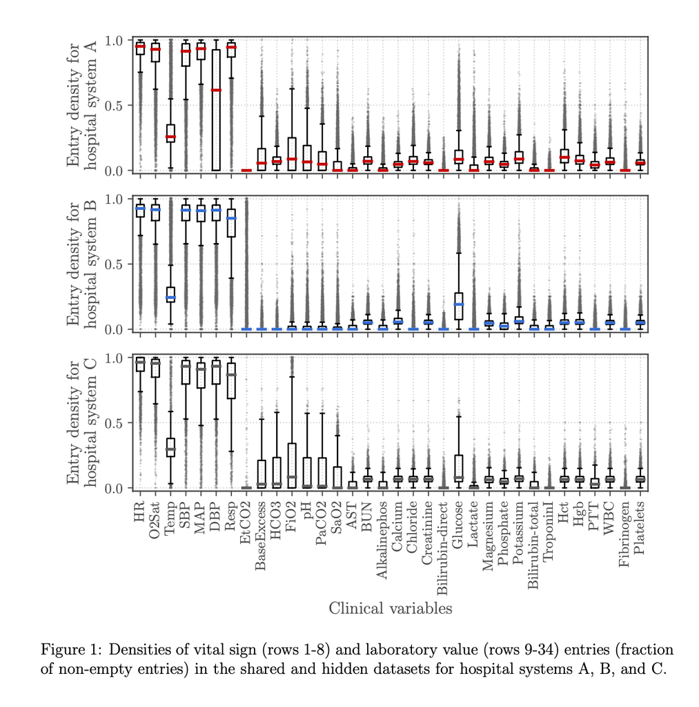

Image obtained from the official pdf of the PhysioNet Challenge. The image gives an overall idea of the number of records available for each feature, for all the three datasets of three different hospitals.

```python
# the features have been removed based to match the target domain dataset

columns_drop={'Unnamed: 0','EtCO2','BaseExcess', 'HCO3','Alkalinephos','Fibrinogen','Unit1','Unit2', 'Platelets', 'AST', 'HospAdmTime','Unit1', 'Unit2'}
df_train_mod = df.drop(columns=columns_drop)
df_train_mod.columns
```

```
Index(['Hour', 'HR', 'O2Sat', 'Temp', 'SBP', 'MAP', 'DBP', 'Resp', 'FiO2',
       'pH', 'PaCO2', 'SaO2', 'BUN', 'Calcium', 'Chloride', 'Creatinine',
       'Bilirubin_direct', 'Glucose', 'Lactate', 'Magnesium', 'Phosphate',
       'Potassium', 'Bilirubin_total', 'TroponinI', 'Hct', 'Hgb', 'PTT', 'WBC',
       'Age', 'Gender', 'ICULOS', 'SepsisLabel', 'Patient_ID'],
      dtype='str')
```

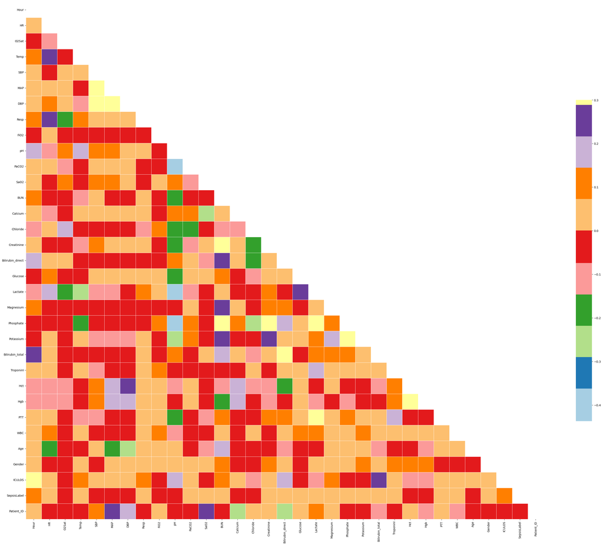

```python
# correlation matrix to check if there is high correlation between the remaining features

corr_matrix(df_train_mod)
```

As can be seen in this correlation heat map almost all of the feature do not have high correlation.